# Data Mining (CS4S767) - Practical Coursework 1

Nitharshana Thayanantham (Student Number - 30119539)

2025-02-04

## **1. Task A - Text Mining**

The goal is to preprocess and analyze the text data in the description column of the data set to gain insights and visualize trends.

### **1.1 Loading and Inspecting the Data**

### **1.1.1 Loading Necessary Libraries**

To ensure that the necessary functions are available, the required libraries must be installed and loaded.

```r
libraries <- c("tm","readr", "tidytext", "ggplot2", "wordcloud", "dplyr", "textstem", "textdata","tidyr","tidyverse","SnowballC","igraph","ggraph","naniar","lubridate","topicmodels","cluster","factoextra","textmineR","LDAvis","servr","sentimentr","slam","stm","stopwords")

#install.packages(libraries) # Comment out after first execution

for (lib in libraries) {
  library(lib, character.only=TRUE)
}
```

### **1.1.2 Reading the Dataset**

The dataset is imported using read_csv()

```r
file_path <- "E:/USW/sem02/datamining/assignment01/submission/MS4S09_CW_Reviews.csv"
# Load the dataset
df <- read_csv(file_path, locale = locale(encoding = "latin1"))
# Display the first few rows
head(df)
```

```
## # A tibble: 6 × 14
##   ...1  country  description designation points price province region_1 region_2
##   <chr> <chr>    <chr>       <chr>        <dbl> <dbl> <chr>    <chr>    <chr>
## 1 0     Italy    Aromas inc… VulkÃ  Bia…     87    NA Sicily … Etna     <NA>
## 2 1     Portugal This is ri… Avidagos        87    15 Douro    <NA>     <NA>
## 3 2     US       Tart and s… <NA>            87    14 Oregon   Willame… Willame…
## 4 3     US       Pineapple … Reserve La…     87    13 Michigan Lake Mi… <NA>
## 5 4     US       Much like … Vintner's …     87    65 Oregon   Willame… Willame…
## 6 5     Spain    Blackberry… Ars In Vit…     87    15 Norther… Navarra  <NA>
## # ℹ 5 more variables: taster_name <chr>, taster_twitter_handle <chr>,
## #   title <chr>, variety <chr>, winery <chr>
```

### **1.1.3 Checking Dataset Structure**

To understand the dataset’s structure, the str() function is applied, displaying the column names along with their data types.

```r
# Check dataset structure
str(df)
```

```
## spc_tbl_ [133,189 × 14] (S3: spec_tbl_df/tbl_df/tbl/data.frame)
##  $ ...1                 : chr [1:133189] "0" "1" "2" "3" ...
##  $ country              : chr [1:133189] "Italy" "Portugal" "US" "US" ...
##  $ description          : chr [1:133189] "Aromas include tropical fruit, broom, brimstone and dried herb. The palate isn't overly expressive, offering un"| __truncated__ "This is ripe and fruity, a wine that is smooth while still structured. Firm tannins are filled out with juicy r"| __truncated_…
##  $ designation          : chr [1:133189] "VulkÃ  Bianco" "Avidagos" NA "Reserve Late Harvest" ...
##  $ points               : num [1:133189] 87 87 87 87 87 87 87 87 87 87 ...
##  $ price                : num [1:133189] NA 15 14 13 65 15 16 24 12 27 ...
##  $ province             : chr [1:133189] "Sicily & Sardinia" "Douro" "Oregon" "Michigan" ...
##  $ region_1             : chr [1:133189] "Etna" NA "Willamette Valley" "Lake Michigan Shore" ...
##  $ region_2             : chr [1:133189] NA NA "Willamette Valley" NA ...
##  $ taster_name          : chr [1:133189] "Kerin Oâ\u0080\u0099Keefe" "Roger Voss" "Paul Gregutt" "Alexander Peartree" ...
##  $ taster_twitter_handle: chr [1:133189] "@kerinokeefe" "@vossroger" "@paulgwineÂ " NA ...
##  $ title                : chr [1:133189] "Nicosia 2013 VulkÃ  Bianco  (Etna)" "Quinta dos Avidagos 2011 Avidagos Red (Douro)" "Rainstorm 2013 Pinot Gris (Willamette Valley)" "St. Julian 2013 Reserve Late Harvest Riesling (Lake Michigan Shore)" ...
##  $ variety              : chr [1:133189] "White Blend" "Portuguese Red" "Pinot Gris" "Riesling" ...
##  $ winery               : chr [1:133189] "Nicosia" "Quinta dos Avidagos" "Rainstorm" "St. Julian" ...
##  - attr(*, "spec")=
##   .. cols(
##   ..   ...1 = col_character(),
##   ..   country = col_character(),
##   ..   description = col_character(),
##   ..   designation = col_character(),
##   ..   points = col_double(),
##   ..   price = col_double(),
##   ..   province = col_character(),
##   ..   region_1 = col_character(),
##   ..   region_2 = col_character(),
##   ..   taster_name = col_character(),
##   ..   taster_twitter_handle = col_character(),
##   ..   title = col_character(),
##   ..   variety = col_character(),
##   ..   winery = col_character()
##   .. )
##  - attr(*, "problems")=<externalptr>
```

Additionally, the summary() function is utilized to obtain descriptive statistics for numerical columns.

```r
# Summary statistics of the dataset
summary(df)
```

```
##      ...1             country          description        designation
##  Length:133189      Length:133189      Length:133189      Length:133189
##  Class :character   Class :character   Class :character   Class :character
##  Mode  :character   Mode  :character   Mode  :character   Mode  :character
##
##
##
##
##      points           price          province           region_1
##  Min.   : 80.00   Min.   :   4.0   Length:133189      Length:133189
##  1st Qu.: 86.00   1st Qu.:  17.0   Class :character   Class :character
##  Median : 88.00   Median :  25.0   Mode  :character   Mode  :character
##  Mean   : 88.44   Mean   :  35.4
##  3rd Qu.: 91.00   3rd Qu.:  42.0
##  Max.   :100.00   Max.   :3300.0
##  NA's   :8672     NA's   :17289
##    region_2         taster_name        taster_twitter_handle    title
##  Length:133189      Length:133189      Length:133189         Length:133189
##  Class :character   Class :character   Class :character      Class :character
##  Mode  :character   Mode  :character   Mode  :character      Mode  :character
##
##
##
##
##    variety             winery
##  Length:133189      Length:133189
##  Class :character   Class :character
##  Mode  :character   Mode  :character
##
##
##
##
```

### **1.2. Handling Missing Data**

Upon identifying the presence of missing values, appropriate strategies are implemented.

### **1.2.1 Identifying Missing Values**

To determine the extent of missing data, the number of missing values in each column is counted.

```r
# Count missing values per column
colSums(is.na(df))
```

```
##                  ...1               country           description
##                     0                  4396                  4336
##           designation                points                 price
##                 44608                  8672                 17289
##              province              region_1              region_2
##                  8732                 29021                 84824
##           taster_name taster_twitter_handle                 title
##                 33646                 38399                  8672
##               variety                winery
##                  8674                  8673
```

### **1.2.2 Removing or Imputing Missing Values**

**For text-based analysis (description column)**

Reviews with missing description values are removed, as they provide no textual information.This is executed using the filter() function.

**For numerical data (points and price columns)**

- Missing values in points can be imputed with the median score.
- Missing values in price can also be imputed using the median, as price distributions are often skewed.

```r
# Remove rows where 'description' is missing
df <- df %>% filter(!is.na(description))

# Impute missing numerical values with median
df$points[is.na(df$points)] <- median(df$points, na.rm = TRUE)
df$price[is.na(df$price)] <- median(df$price, na.rm = TRUE)

# Count missing values per column
colSums(is.na(df))
```

```
##                  ...1               country           description
##                     0                    60                     0
##           designation                points                 price
##                 40272                     0                     0
##              province              region_1              region_2
##                  4396                 24685                 80488
##           taster_name taster_twitter_handle                 title
##                 29310                 34063                  4336
##               variety                winery
##                  4338                  4337
```

In my analysis, sentiment was evaluated based on points, but price was not incorporated. However, in future analyses, price will be included to examine its correlation with sentiment for deeper insights.

The points and price columns initially had 4,336 and 12,953 missing values, respectively. While these did not impact the analysis, retaining the rows was crucial for accuracy. After applying imputation techniques, missing values in points and price were reduced to zero. Description initially had (4336) missing values which is removed from dataset.

### **1.3. Handling Outliers**

There are only two numeric columns in the dataset such as price and points. I used the Interquartile Range (IQR) method to detect and highlight outliers through overlaid boxplots.

**Outliers in points and price are identified using boxplots.**

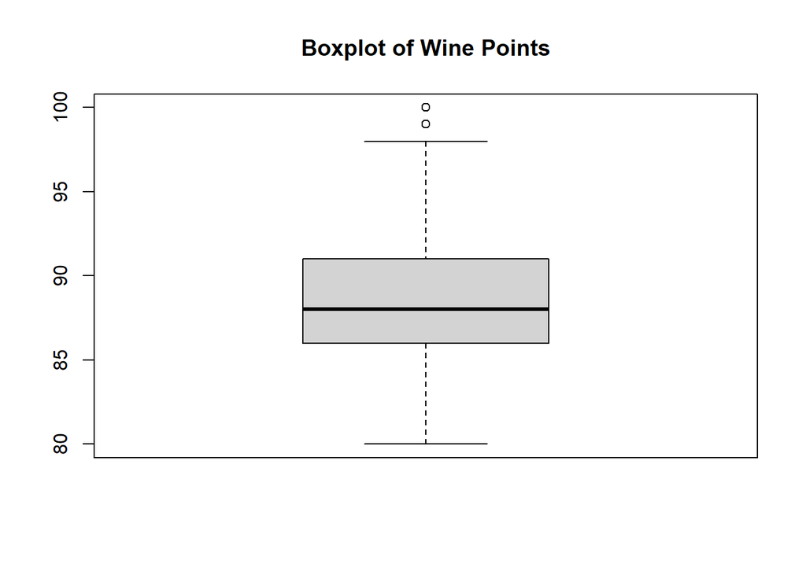

```r
boxplot(df$points, main = "Boxplot of Wine Points")
```

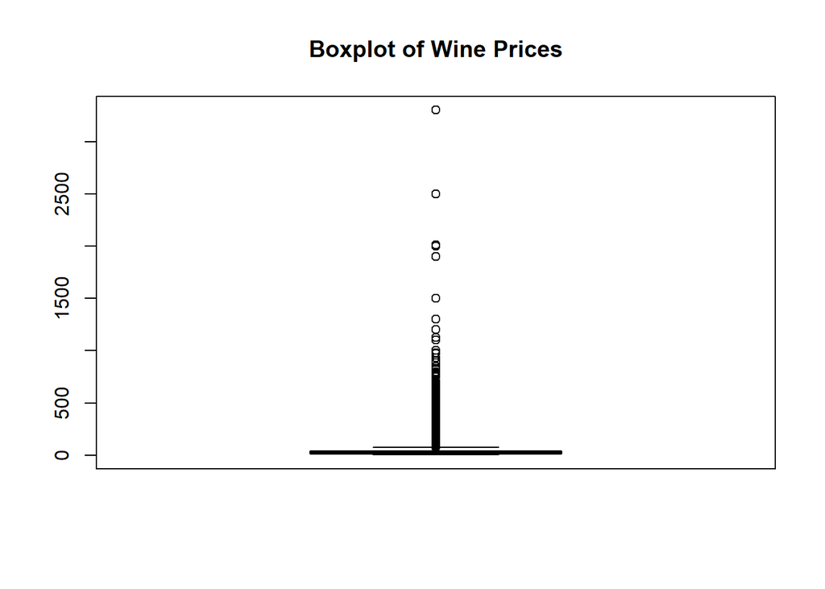

```r
boxplot(df$price, main = "Boxplot of Wine Prices")
```

**Outliers are replaced with the interquartile range (IQR) method.**

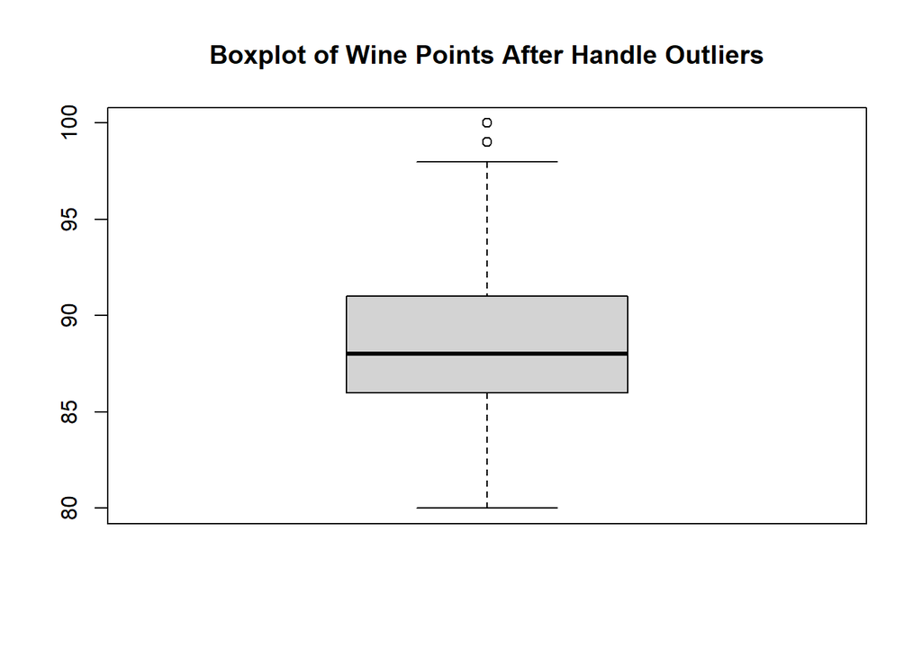

```r
# Define IQR limits for price
Q1 <- quantile(df$price, 0.25, na.rm = TRUE)
Q3 <- quantile(df$price, 0.75, na.rm = TRUE)
IQR_value <- Q3 - Q1

# Define lower and upper bounds
lower_bound <- Q1 - 1.5 * IQR_value
upper_bound <- Q3 + 1.5 * IQR_value

# Replace extreme values with upper bound
df$price[df$price > upper_bound] <- upper_bound
df$price[df$price < lower_bound] <- lower_bound

boxplot(df$points, main = "Boxplot of Wine Points After Handle Outliers")
```

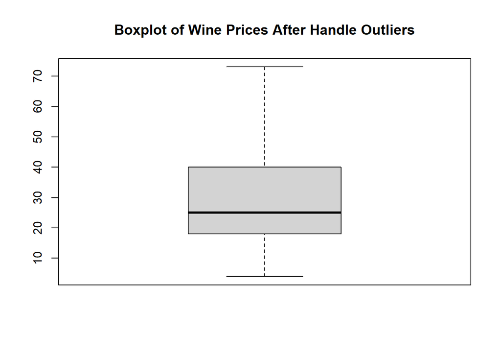

```r
boxplot(df$price, main = "Boxplot of Wine Prices After Handle Outliers")
```

### **1.4. Sampling the Data**

The dataset, containing 133,189 rows, was considered quite large. For computational power concerns, a subset of 20,000 reviews was sampled for quicker analysis.

**Description** contains the wine reviews written by tasters. This is the primary column for this analysis. title might contain useful keywords but is less relevant than description. and **points** can be use in sentiment analysis.

```r
# Sample 20,000 rows randomly for analysis
set.seed(123)  # Ensures reproducibility
df_sampled <- df %>% sample_n(20000)
```

### **1.5. Text Preprocessing for Analysis**

Before conducting Text Mining, Sentiment Analysis, and Topic Modelling, the text data must be cleaned.

```r
#Before Cleaning Data
head(df_sampled$description)
```

```
## [1] "Happily, each new vintage of BÃ©soleil is a bit larger than the previous year, so more people can taste what a joy this wine is. In 2008 it's 82% Grenache, 9% Syrah and 9% MourvÃ¨dre. As with all the Betz wines, it is intensely aromatic. The wine glass fairly explodes with scents of grape, p…
## [2] "Tropical aromas of lychee and banana come with a varietally familiar note of bath soap. This is oily feeling, but with integrated acidity it isn't ponderous. Pithy citrus flavors are backed by a hint of bitterness, while the finish is juicy, a touch burning and tastes of nectarine and mango.…
## [3] "This big, dramatic wine has a dark color and bold aromas of wood smoke and black pepper. Flavors are concentrated but also dry and appetizing. Firm tannins add grip and seem to help the peppery, smoky accents linger on the finish. Best after 2020."
## [4] "This is appealing from the beginning, with fresh raspberry, strawberry and mineral aromas. It feels nice and bright, with flavors of citrus, pink grapefruit and green herb. Finishes with forward acidity and mild flavors of sage and tarragon."
## [5] "Central Otago Pinot Noir doesn't come along very often at this price. This medium-weight, peppery wine doesn't show a ton of fruit, but does deliver some pleasantly spicy complexity and a mouthwatering chocolaty finish. Drink now."
## [6] "Reduced on the nose, this massively intense and tannic wine is big, dense and juicy, broadly etched in leather, blackberry, currant and black licorice. Full-bodied and oaky, it shows the concentration of the vintage and the ripeness of the appellation and style."
```

### **1.5.1 Apply Text Preprocessing**

Preprocessing cleans and prepares text data for analysis by removing noise and irrelevant information.

Key techniques include:

- **Lowercasing:** Convert all text to lowercase for uniformity and maintain consistency.
- **Removing Punctuation:** Remove all punctuation marks to focus only on meaningful words.
- **Removing Numbers:** Remove numeric values unless they are relevant.
- **Removing Special Characters:** Clean up non-alphabetic characters.
- **Removing Stop Words:** Eliminate common words that do not add meaning.
- **Tokenization:** Split text into individual words or tokens.
- **Stemming:** Reduce words to their root forms.
- **Lemmatization:** Convert words to their base forms based on context.
- **N-grams:** Generate sequences of n words to identify common phrases.

```r
# Convert encoding and remove problematic characters
df_sampled$description <- iconv(df_sampled$description, from = "latin1", to = "UTF-8", sub = "")
df_sampled$description <- gsub("[^[:alnum:] ]", "", df_sampled$description)

# Lowercase
df_sampled$description <- tolower(df_sampled$description)

# Tokenization and stop words removal
data_clean <- df_sampled %>%
  unnest_tokens(word, description) %>%
  anti_join(stop_words, by = "word")

# Define a custom stopword list (combine predefined and custom words)
custom_stopwords <- c(stopwords("en"), "wine", "flavors", "taste", "bottle", "glass", "drink")

# Remove meaningless words (stopwords)
data_clean <- data_clean %>%
  filter(!word %in% custom_stopwords)

print(head(data_clean))
```

```
## # A tibble: 6 × 14
##   ...1  country designation points price province  region_1 region_2 taster_name
##   <chr> <chr>   <chr>        <dbl> <dbl> <chr>     <chr>    <chr>    <chr>
## 1 52780 US      BÃ©soleil       93    45 Washingt… Columbi… Columbi… Paul Gregu…
## 2 52780 US      BÃ©soleil       93    45 Washingt… Columbi… Columbi… Paul Gregu…
## 3 52780 US      BÃ©soleil       93    45 Washingt… Columbi… Columbi… Paul Gregu…
## 4 52780 US      BÃ©soleil       93    45 Washingt… Columbi… Columbi… Paul Gregu…
## 5 52780 US      BÃ©soleil       93    45 Washingt… Columbi… Columbi… Paul Gregu…
## 6 52780 US      BÃ©soleil       93    45 Washingt… Columbi… Columbi… Paul Gregu…
## # ℹ 5 more variables: taster_twitter_handle <chr>, title <chr>, variety <chr>,
## #   winery <chr>, word <chr>
```

```r
 # Remove special characters
data_clean$word <- gsub("[^a-zA-Z\\s]", "", data_clean$word)

# Remove numbers
data_clean$word <- gsub("[0-9]", "", data_clean$word)

# Remove NA and empty words
data_clean <- data_clean %>%
  filter(!is.na(word) & word != "")

#Removing Punctuation
data_clean$word <- gsub("[[:punct:]]", "", data_clean$word)

# Stemming
data_clean$stemmed_word <- wordStem(data_clean$word)

# Lemmatization
data_clean$lemmatized_word <- textstem::lemmatize_words(data_clean$stemmed_word)

print(head(data_clean))
```

```
## # A tibble: 6 × 16
##   ...1  country designation points price province  region_1 region_2 taster_name
##   <chr> <chr>   <chr>        <dbl> <dbl> <chr>     <chr>    <chr>    <chr>
## 1 52780 US      BÃ©soleil       93    45 Washingt… Columbi… Columbi… Paul Gregu…
## 2 52780 US      BÃ©soleil       93    45 Washingt… Columbi… Columbi… Paul Gregu…
## 3 52780 US      BÃ©soleil       93    45 Washingt… Columbi… Columbi… Paul Gregu…
## 4 52780 US      BÃ©soleil       93    45 Washingt… Columbi… Columbi… Paul Gregu…
## 5 52780 US      BÃ©soleil       93    45 Washingt… Columbi… Columbi… Paul Gregu…
## 6 52780 US      BÃ©soleil       93    45 Washingt… Columbi… Columbi… Paul Gregu…
## # ℹ 7 more variables: taster_twitter_handle <chr>, title <chr>, variety <chr>,
## #   winery <chr>, word <chr>, stemmed_word <chr>, lemmatized_word <chr>
```

### **1.5.2 Exploratory Visualization**

The goal is to understand frequent words in wine reviews before moving to deeper analysis. The following visualizations will be generated: Bar Chart

**Bar Chart- Displays the top 20 most frequent words after cleaning.**

The most common words used by wine tasters are displayed. This helps identify recurring themes in customer reviews.

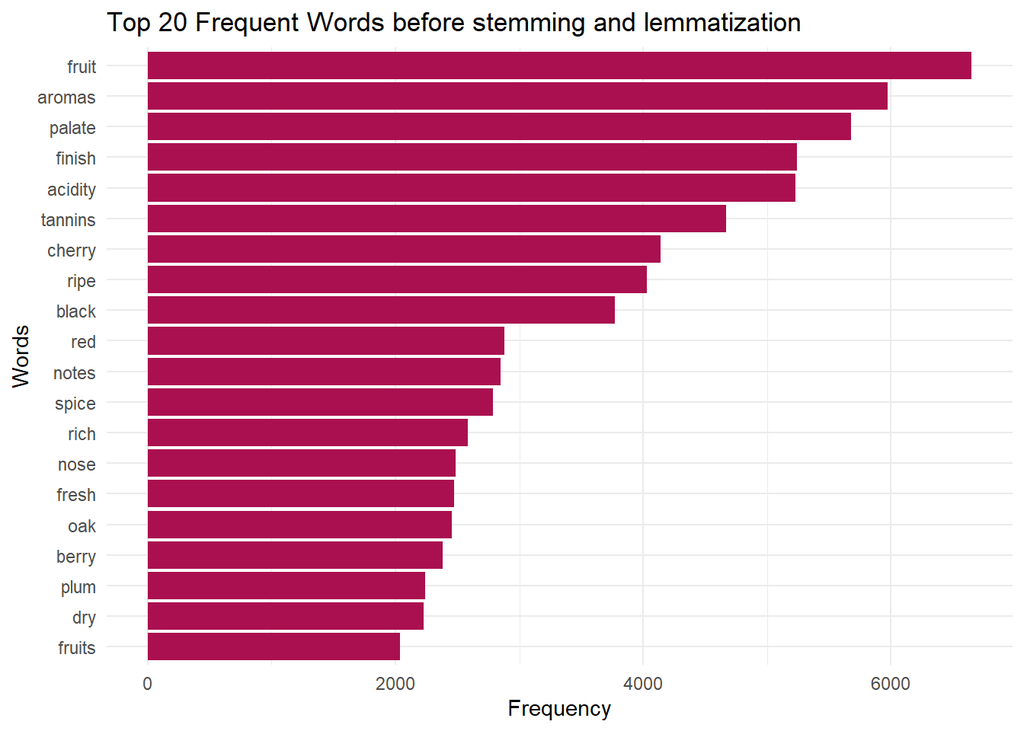

```r
#  Top words before stemming and lemmatization
word_freq <- data_clean %>%
  count(word, sort = TRUE) %>%
  slice_max(n, n = 20)  # Select top 20 most frequent words

# Create the bar chart
ggplot(word_freq, aes(x = reorder(word, n), y = n)) +
  geom_bar(stat = "identity", fill = "#AA104F") +
  coord_flip() +
  labs(title = "Top 20 Frequent Words before stemming and lemmatization",
       x = "Words", y = "Frequency") +
  theme_minimal()
```

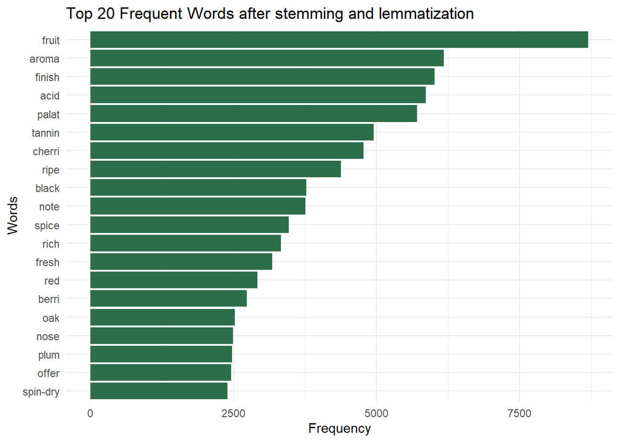

```r
#  Top words After stemming and lemmatization
word_freq <- data_clean %>%
  count(lemmatized_word, sort = TRUE) %>%
  slice_max(n, n = 20)  # Select top 20 most frequent words

# Create the bar chart
ggplot(word_freq, aes(x = reorder(lemmatized_word, n), y = n)) +
  geom_bar(stat = "identity", fill = "#2C6E49") +
  coord_flip() +
  labs(title = "Top 20 Frequent Words after stemming and lemmatization",
       x = "Words", y = "Frequency") +
  theme_minimal()
```

**Word cloud - Shows the most frequent words in reviews.**

Larger words indicate more frequent words in the dataset.Words like “aroma”, “fruit”, “tannin” may appear frequently in wine reviews.

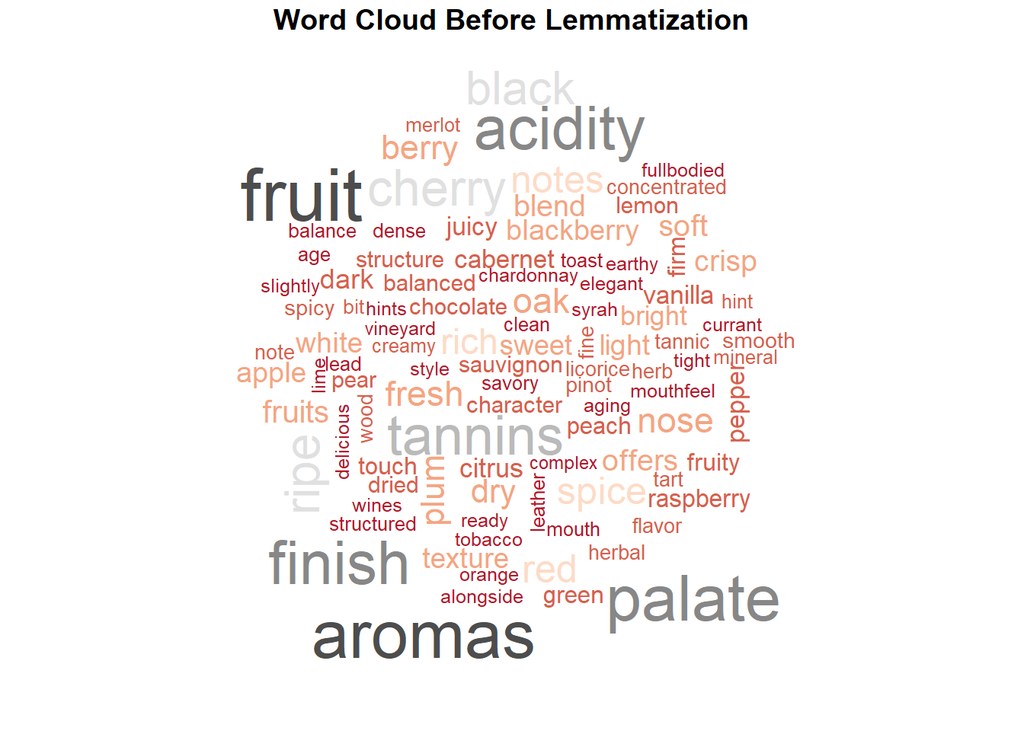

```r
# Word cloud Before Lemmatization
word_freq <- data_clean %>%
  count(word, sort = TRUE)

par(mar = c(0, 0, 0, 0))
wordcloud(words = word_freq$word, freq = word_freq$n,
          max.words = 100, colors = brewer.pal(8, "RdGy"), scale = c(3, 0.5))
title("Word Cloud Before Lemmatization", line = -1)
```

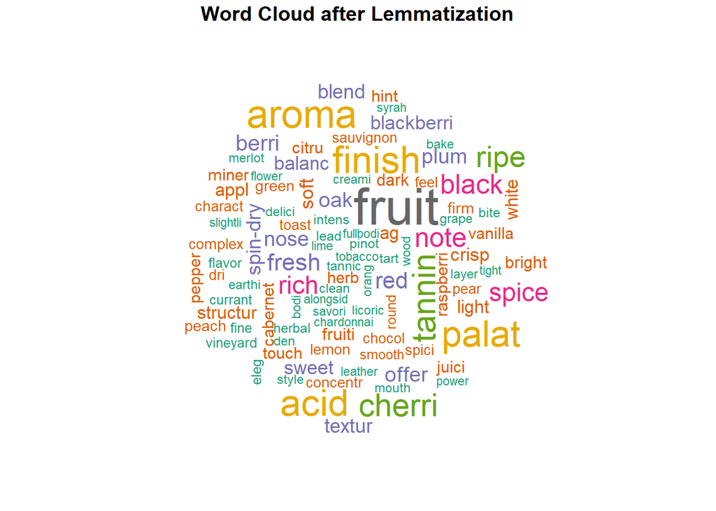

```r
# Word cloud after Lemmatization
lemma_freq <- data_clean %>%
  count(lemmatized_word, sort = TRUE)

par(mar = c(0, 0, 0, 0))
wordcloud(words = lemma_freq$lemmatized_word, freq = lemma_freq$n,
          max.words = 100, colors = brewer.pal(8, "Dark2"), scale = c(3, 0.5))
title("Word Cloud after Lemmatization", line = -1)
```

**Before Cleaning:**

- The dataset contained numbers, special characters, and stopwords, which distorted word frequency analysis.
- The most frequent words included irrelevant words such as “the,” “and,” and “is,” which did not contribute to meaningful insights.

**After Cleaning:** - Numbers and special characters were successfully removed.

- Stopwords were eliminated, and words were standardized using lemmatization.
- The word cloud and bar chart showed more meaningful words related to wine characteristics (e.g., “fruity,” “aroma,” “oak”).

### **1.5.3 Bigram Analysis**

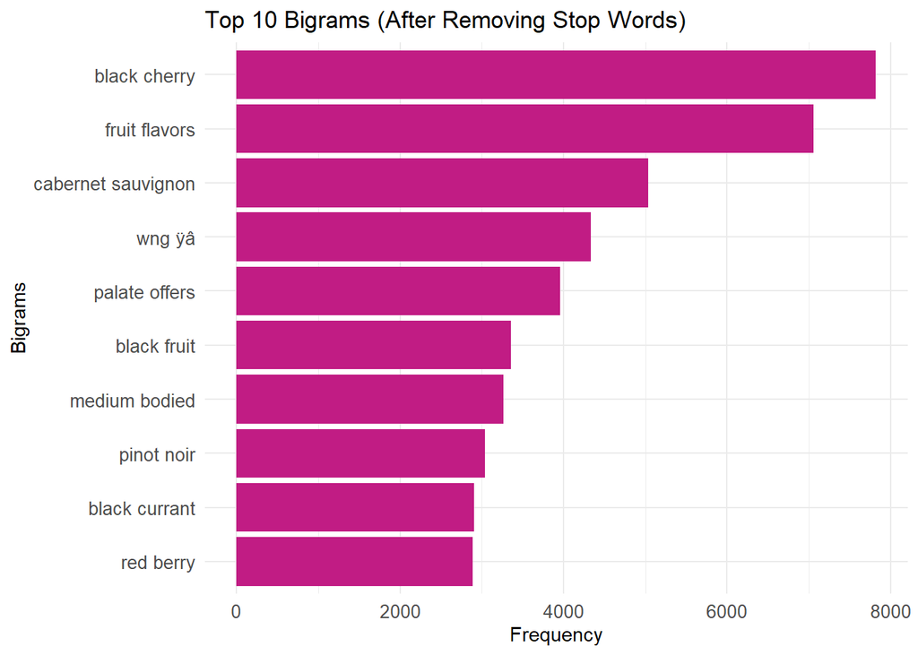

```r
# Extract bigrams
bigrams <- df %>%
  unnest_tokens(bigram, description, token = "ngrams", n = 2)

# Remove bigrams with stop words
bigrams_clean <- bigrams %>%
  separate(bigram, into = c("word1", "word2"), sep = " ") %>%
  filter(!word1 %in% stop_words$word, !word2 %in% stop_words$word) %>%
  unite(bigram, word1, word2, sep = " ")

# Get top 10 bigrams by frequency
top_bigrams <- bigrams_clean %>%
  count(bigram, sort = TRUE) %>%
  slice_max(n, n = 10)

# Visualization: Top 10 Bigrams
ggplot(top_bigrams, aes(x = reorder(bigram, n), y = n)) +
  geom_bar(stat = "identity", fill = "#C11C84") +
  coord_flip() +
  labs(title = "Top 10 Bigrams (After Removing Stop Words)",
       x = "Bigrams", y = "Frequency") +
  theme_minimal() +
  theme(axis.text.x = element_text(size = 10), axis.text.y = element_text(size = 10))
```

The image is a bar chart showing the top 10 most frequent bigrams (word pairs) in a dataset after removing stop words. The x-axis represents the frequency of occurrence, while the y-axis lists the bigrams.

The most frequent bigram is “black cherry,” followed by “fruit flavors” and “cabernet sauvignon,” which are common terms used in wine descriptions.

Other notable bigrams include “pinot noir,” “black currant,” and “medium bodied,” indicating that the dataset likely pertains to wine reviews or descriptions. The presence of “wng yã” suggests a possible data artifact or encoding issue.

### **1.5.4 Network Graph for Bigrams**

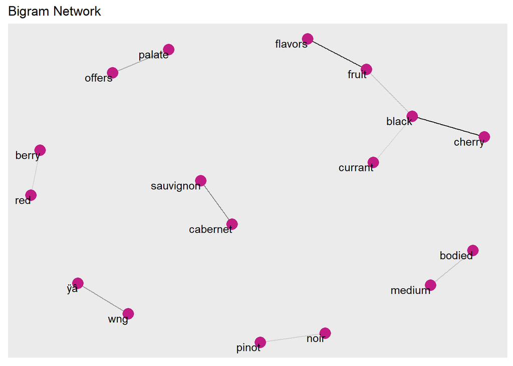

```r
bigram_graph <- top_bigrams %>%
  separate(bigram, into = c("word1", "word2"), sep = " ") %>%
  filter(n > 2) %>%
  graph_from_data_frame()

ggraph(bigram_graph, layout = "fr") +
  geom_edge_link(aes(edge_alpha = n), show.legend = FALSE) +
  geom_node_point(color = "#C11C84", size = 5) +
  geom_node_text(aes(label = name), vjust = 1, hjust = 1) +
  labs(title = "Bigram Network")
```

The image represents a bigram network, which is a visualization of word pairs (bigrams) and their connections in a dataset, likely related to wine descriptions.

Each pink node represents a word, and the edges (lines) between them indicate a meaningful co-occurrence. Some notable word pairs include “black currant,” “red berry,” “pinot noir,” and “cabernet sauvignon,” all of which are common wine-related terms. The network structure highlights clusters of related terms, showing how words are frequently paired together in the given text.

## **2. Task B - Sentiment Analysis**

Sentiment analysis for identifying and categorizing opinions expressed in a piece of text (Description).

### **2.1. Application of Lexicons**

### **2.1.1 Sentiment Scoring with AFINN Lexicon**

Calculate numerical sentiment scores for each review.

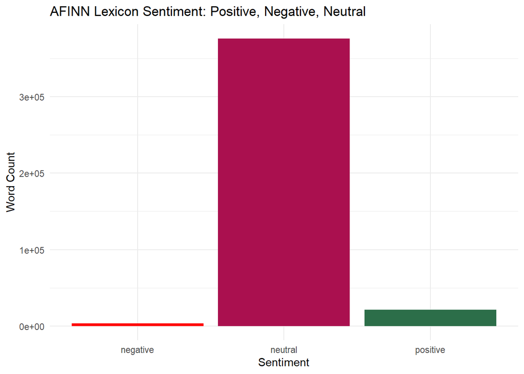

```r
# AFINN sentiment scoring with Neutral included
afinn_sentiments <- get_sentiments("afinn")  # Load AFINN lexicon

afinn_results <- data_clean %>%
  left_join(afinn_sentiments, by = c("lemmatized_word" = "word")) %>%
  mutate(sentiment = case_when(
    value > 0 ~ "positive",
    value < 0 ~ "negative",
    TRUE ~ "neutral"  # Assign neutral where value == 0
  )) %>%
  count(sentiment, sort = TRUE)

# Bar chart: Positive, Negative, Neutral
ggplot(afinn_results, aes(x = sentiment, y = n, fill = sentiment)) +
  geom_bar(stat = "identity", show.legend = FALSE) +
  scale_fill_manual(values = c("positive" = "#2C6E49", "negative" = "red", "neutral" = "#AA104F")) +
  labs(title = "AFINN Lexicon Sentiment: Positive, Negative, Neutral",
       x = "Sentiment", y = "Word Count") +
  theme_minimal()
```

**In this Analysis**

Neutral Sentiment Dominates – The tallest bar, in dark maroon, represents neutral words, indicating that the majority of the words analyzed have no strong positive or negative sentiment.

Positive vs. Negative – The green bar represents positive words, while the red bar represents negative words. There are more positive words than negative ones, but both are significantly lower compared to neutral words.

This could suggest that the text analyzed is mostly neutral, with a small proportion of positive and negative sentiments. This is common in general text analysis, where many words do not carry strong emotional weight. If we omit neutral reviews, positive reviews take the dominant position in this analysis.

### **2.1.2 Sentiment Analysis with Bing Lexicon**

Analyze the sentiment as positive , negative using the Bing lexicon.

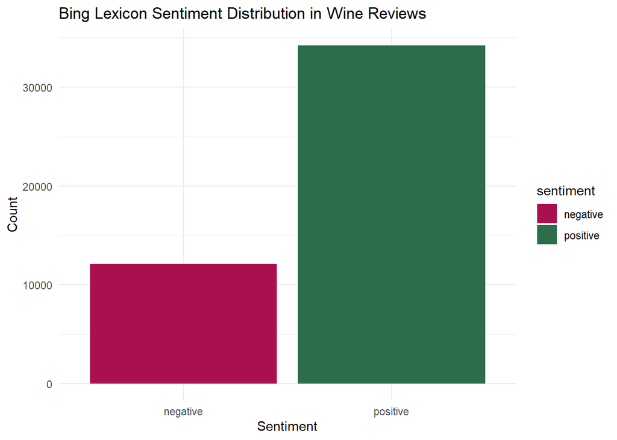

```r
# Bing sentiment analysis
bing_sentiments <- get_sentiments("bing")  # Load Bing lexicon

# Join with cleaned words for sentiment analysis
sentiment_analysis <- data_clean %>%
  inner_join(bing_sentiments, by = c("lemmatized_word" = "word"))

# Count sentiment frequency
sentiment_count <- sentiment_analysis %>%
  count(sentiment, sort = TRUE)

ggplot(sentiment_count, aes(x = sentiment, y = n, fill = sentiment)) +
  geom_bar(stat = "identity") +
  scale_fill_manual(values = c("negative" = "#AA104F", "positive" = "#2C6E49")) +
  labs(title = "Bing Lexicon Sentiment Distribution in Wine Reviews", x = "Sentiment", y = "Count") +
  theme_minimal()
```

The bar chart represents the sentiment distribution of wine reviews using the bing lexicon, which assigns a numerical sentiment score to words. categorizing words as positive or negative based on their sentiment.

The x-axis represents the sentiment categories, while the y-axis represents the word count.The positive sentiment category has significantly more reviews compared to the negative sentiment category, indicating that most wine reviews are favorable, while fewer reviews express negative sentiments.

### **2.1.3 Sentiment Analysis with NRC Lexicon**

Analyze emotions such as joy, anger, fear, etc

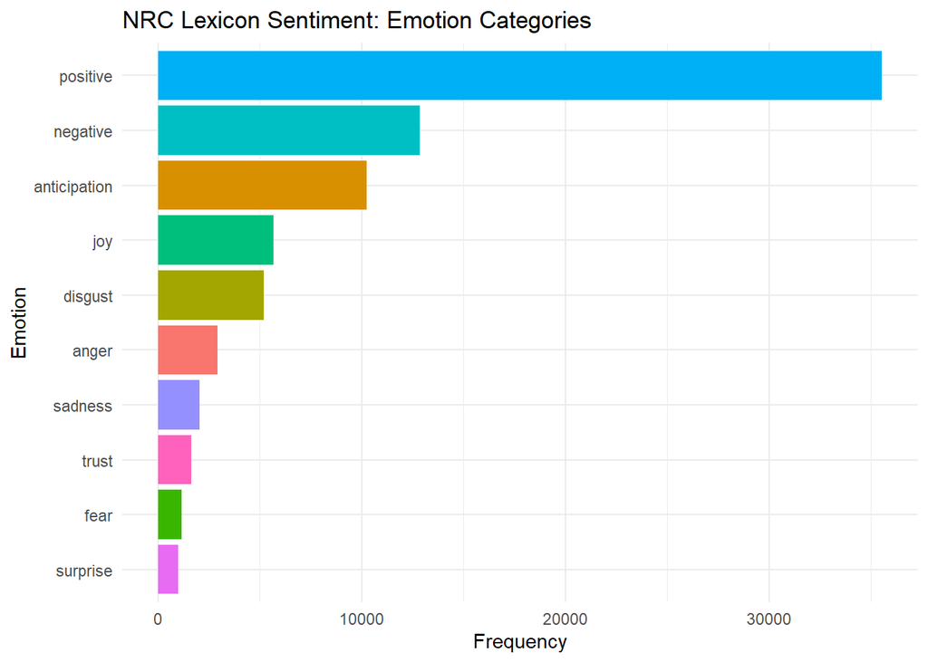

```r
# Load NRC sentiment lexicon
nrc_sentiments <- get_sentiments("nrc")

# Keep only the first occurrence per word (arbitrary choice)
nrc_sentiments_dedup <- nrc_sentiments %>%
  group_by(word) %>%
  slice(1) %>%
  ungroup()

# Perform sentiment analysis with the deduplicated lexicon
nrc_results <- data_clean %>%
  inner_join(nrc_sentiments_dedup, by = c("lemmatized_word" = "word")) %>%
  count(sentiment, sort = TRUE)

# Bar chart: NRC Emotion Categories
ggplot(nrc_results, aes(x = reorder(sentiment, n), y = n, fill = sentiment)) +
  geom_bar(stat = "identity", show.legend = FALSE) +
  coord_flip() +
  labs(title = "NRC Lexicon Sentiment: Emotion Categories",
       x = "Emotion", y = "Frequency") +
  theme_minimal()
```

The bar chart, visualizes the frequency of different emotions in the dataset. **“Positive”** sentiment dominates, with the longest bar, indicating a strong overall positivity.

Other emotions **disgust, anger, trust, sadness, fear, and surprise** are less frequent, with much shorter bars. Overall, the text reflects a strong positive bias with notable anticipation, while other emotions are present but less prominent.

### **2.2. Visualization using Sentiment Scores**

### **2.2.1 Word Clouds for Positive and Negative Words**

Visualize the most frequent positive and negative words.

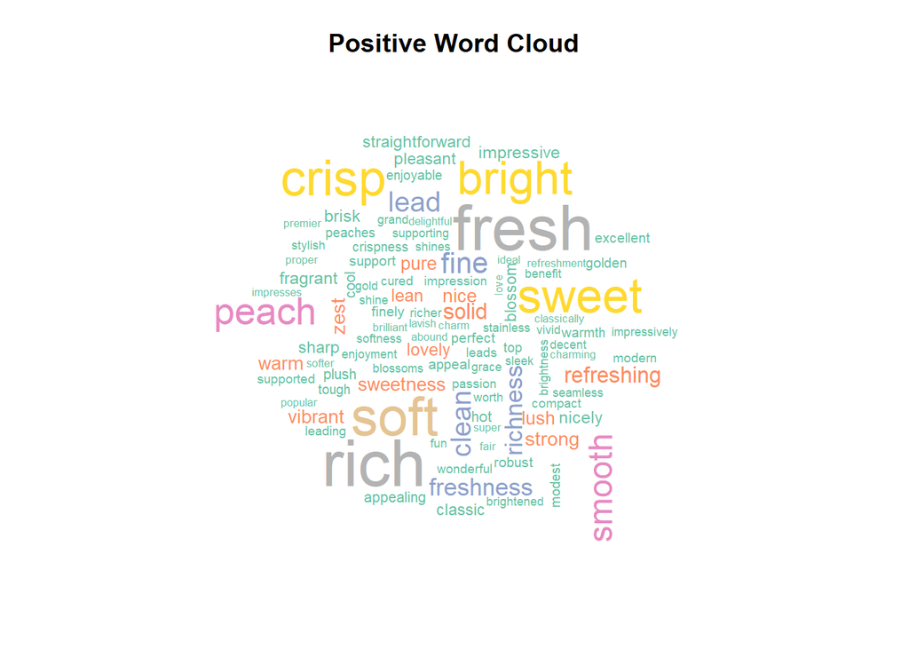

```r
# Positive, Negative and Neutral Word Clouds
positive_words <- data_clean %>%
  inner_join(bing_sentiments %>% filter(sentiment == "positive"), by = c("lemmatized_word" = "word")) %>%
  count(word, sort = TRUE)

negative_words <- data_clean %>%
  inner_join(bing_sentiments %>% filter(sentiment == "negative"), by = c("lemmatized_word" = "word")) %>%
  count(word, sort = TRUE)

neutral_words <- data_clean %>%
  left_join(bing_sentiments, by = "word") %>%
  filter(is.na(sentiment)) %>%
  count(word, sort = TRUE)

# Generate Word Clouds
par(mar = c(0, 0, 0, 0))

wordcloud(words = positive_words$word, freq = positive_words$n,
          max.words = 100, colors = brewer.pal(8, "Set2"), scale = c(3, 0.5))
title("Positive Word Cloud", line = -2)
```

The word cloud highlights positive words, with “fresh,” “soft,” and “rich” as the most prominent, indicating their high frequency or importance.

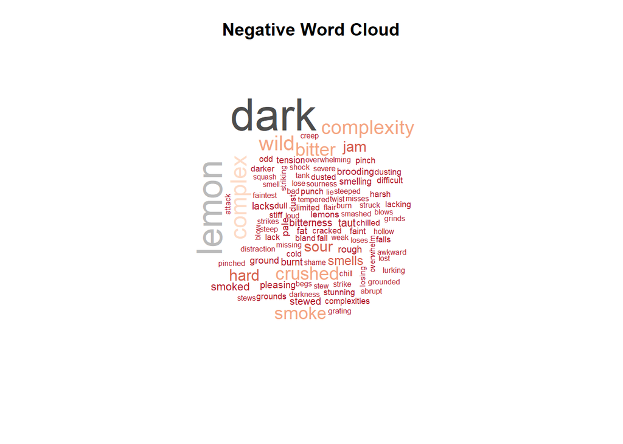

```r
par(mar = c(0, 0, 0, 0))

wordcloud(words = negative_words$word, freq = negative_words$n,
          max.words = 100, colors = brewer.pal(8, "RdGy"), scale = c(3, 0.5))
title("Negative Word Cloud", line = -2)
```

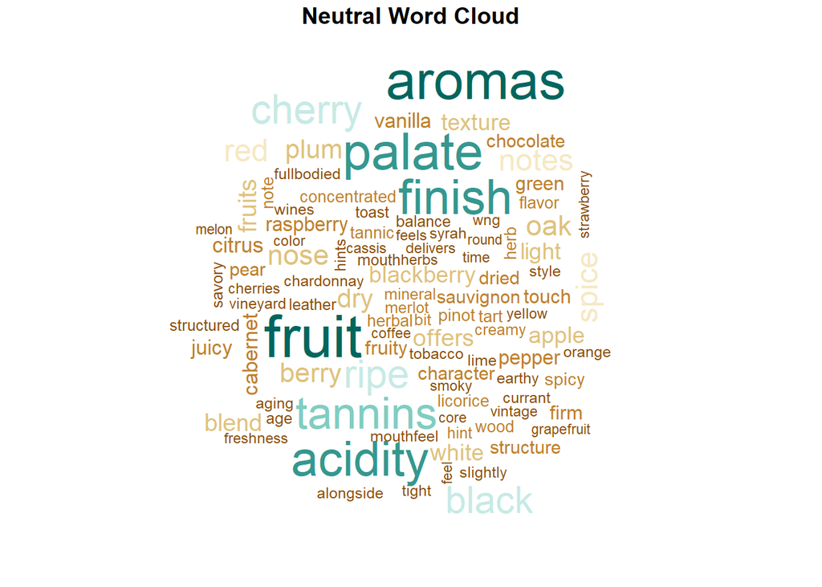

```r
par(mar = c(0, 0, 0, 0))

wordcloud(words = neutral_words$word, freq = neutral_words$n, max.words = 100, colors = brewer.pal(8, "BrBG"), scale = c(3, 0.5))
title("Neutral Word Cloud", line = -1)
```

The neutral tone suggests an emphasis on objective wine descriptions rather than strong sentiments. Overall, the word cloud captures a detailed vocabulary used in wine reviews, highlighting descriptive language without overtly positive or negative connotations.

### **2.2.2 Top Words by Sentiment**

Display top positive and negative words.

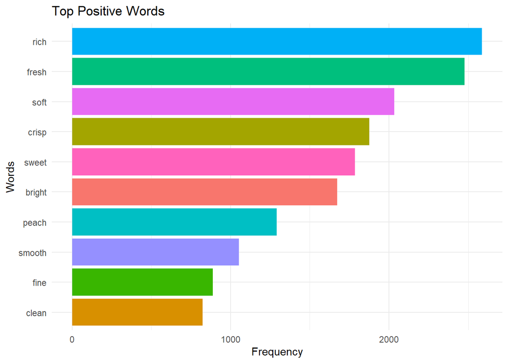

```r
# Top Positive
top_positive <- positive_words %>% top_n(10, n)

# Positive Bar Plot
ggplot(top_positive, aes(x = reorder(word, n), y = n, fill = word)) +
  geom_bar(stat = "identity", show.legend = FALSE) +
  coord_flip() +
  labs(title = "Top Positive Words", x = "Words", y = "Frequency") +
  theme_minimal()
```

Overall, the chart highlights the dominance of certain positive descriptors, emphasizing freshness, richness, and softness in the analyzed text.

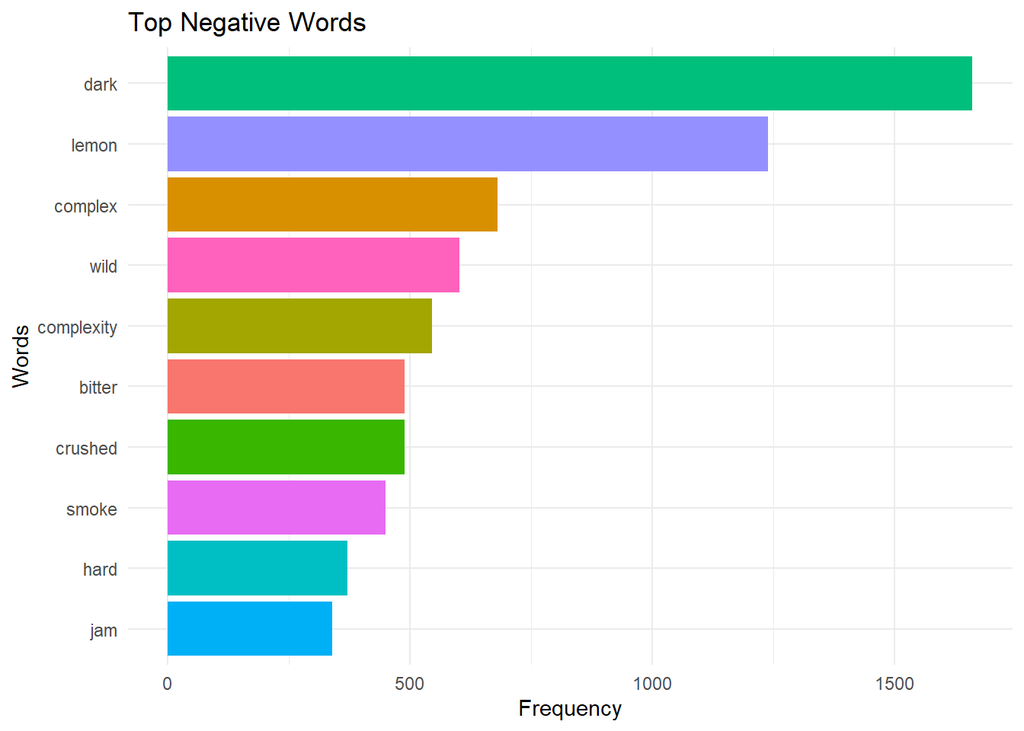

```r
# Top Negative Words
top_negative <- negative_words %>% top_n(10, n)

# Negative Bar Plot
ggplot(top_negative, aes(x = reorder(word, n), y = n, fill = word)) +
  geom_bar(stat = "identity", show.legend = FALSE) +
  coord_flip() +
  labs(title = "Top Negative Words", x = "Words", y = "Frequency") +
  theme_minimal()
```

### **2.2.3 Boxplot of Points vs. Sentiment**

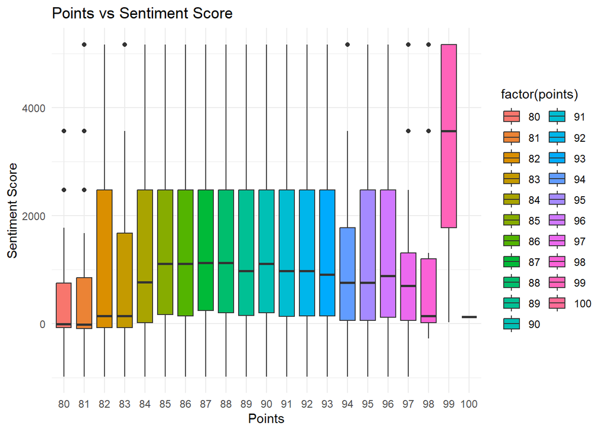

```r
afinn_sentiments <- data_clean %>%
  inner_join(get_sentiments("afinn"), by = c("lemmatized_word" = "word")) %>%
  group_by(word) %>%
  summarise(sentiment_score = sum(value), .groups = "drop")  # Sum sentiment per review

ratings_sentiment <- afinn_sentiments %>%
  inner_join(data_clean %>% select(word, points), by = "word")


#Boxplot of Points vs. Sentiment
ggplot(ratings_sentiment, aes(x = factor(points), y = sentiment_score, fill = factor(points))) +
  geom_boxplot() +
  labs(title = "Points vs Sentiment Score",
       x = "Points", y = "Sentiment Score") +
  theme_minimal()
```

## **3.Task C – Topic Modelling**

The goal of topic modeling is to uncover hidden themes in wine reviews, allowing us to understand common topics that wine tasters discuss. This helps identify trends, preferences, and key characteristics that influence customer opinions.

### **3.1 Prepare Data for Topic Modeling**

Since we have already cleaned the text in Task A, we will proceed with creating a Document-Term Matrix (DTM) for topic modeling.

```r
# Convert the cleaned text into a Corpus
corpus <- Corpus(VectorSource(data_clean$lemmatized_word))

# Create a Document-Term Matrix (DTM)
dtm <- DocumentTermMatrix(corpus)

# Remove sparse terms to improve model efficiency
dtm <- removeSparseTerms(dtm, 0.99)

# Convert DTM to a matrix
dtm_matrix <- as.matrix(dtm)
```

### **3.2. Apply Latent Dirichlet Allocation (LDA) for Topic Modeling**

LDA is one of the most commonly used topic modeling techniques in text mining. It identifies the probability distribution of topics across documents.

```r
row_totals <- apply(dtm, 1, sum)  # Sum of words in each document
dtm <- dtm[row_totals > 0, ]  # Remove empty documents

# Set the number of topics (K) – this can be adjusted
num_topics <- 5

# Apply LDA model
lda_model <- LDA(dtm, k = num_topics, control = list(seed = 1234))

# Extract topic terms
topic_terms <- tidy(lda_model, matrix = "beta")

# Display the top terms for each topic
top_terms <- topic_terms %>%
  group_by(topic) %>%
  slice_max(beta, n = 10) %>%
  ungroup()

# Print top terms for each topic
print(top_terms)
```

```
## # A tibble: 40 × 3
##    topic term     beta
##    <int> <chr>   <dbl>
##  1     1 ripe   0.270
##  2     1 finish 0.194
##  3     1 acid   0.148
##  4     1 fruit  0.124
##  5     1 palat  0.0808
##  6     1 aroma  0.0791
##  7     1 tannin 0.0619
##  8     1 cherri 0.0425
##  9     2 aroma  0.253
## 10     2 cherri 0.175
## # ℹ 30 more rows
```

### **3.3. Visualizing the Topics**

To better understand the extracted topics, we use bar charts to show the most frequent words per topic.

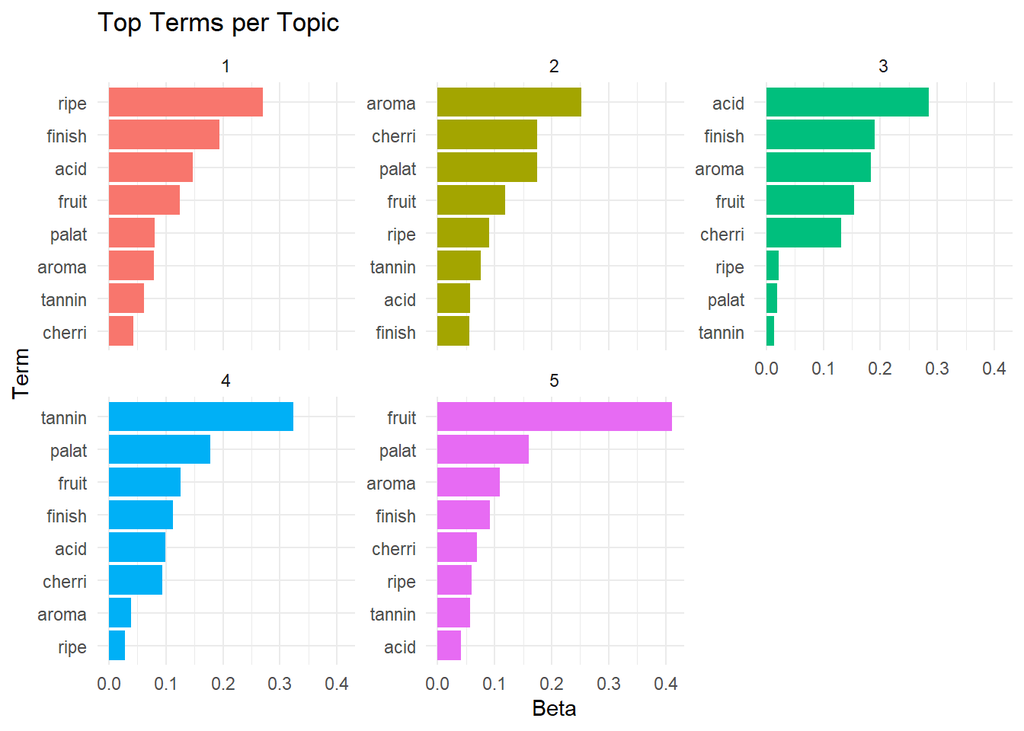

```r
# Visualization of Top Words per Topic
ggplot(top_terms, aes(x = reorder_within(term, beta, topic), y = beta, fill = as.factor(topic))) +
  geom_col(show.legend = FALSE) +
  facet_wrap(~ topic, scales = "free_y") +
  coord_flip() +
  scale_x_reordered() +
  labs(title = "Top Terms per Topic", x = "Term", y = "Beta") +
  theme_minimal()
```

From the visualization, each topic represents a distinct theme in wine reviews. A potential interpretation could be:

**Topic 1 (Red) – Ripeness & Acidity** - Key terms: ripe, finish, acid, fruit, aroma, tannin, cherri - Possible theme: This topic likely discusses the ripeness of fruits and their acidity levels, possibly in the context of wine or fruit tasting.

**Topic 2 (Olive Green) – Aroma & Flavor Profiles** - Key terms: aroma, cherri, palat, fruit, ripe, tannin, finish - Possible theme: Focuses on aromas and tasting notes, possibly describing the sensory aspects of wine, food, or beverages.

**Topic 3 (Teal Blue) – Acidity & Mouthfeel** - Key terms: acid, finish, aroma, fruit, cherri, ripe, palat, tannin - Possible theme: Discusses acidity and finish, which are important factors in wine or beverage quality. The mention of “palat” suggests it relates to mouthfeel and taste balance.

**Topic 4 (Blue) – Tannin & Structure** - Key terms: tannin, palat, fruit, finish, acid, cherri, aroma, ripe - Possible theme: This topic likely focuses on tannins and their effect on texture, particularly in wine, as tannins influence astringency and aging potential.

**Topic 5 (Pink/Purple) – Fruit-forward Characteristics** - Key terms: fruit, palat, aroma, cherri, ripe, tannin, acid - Possible theme: Likely describes fruit-forward wines or beverages, emphasizing flavors of cherries, ripeness, and overall fruit intensity.

## **4.Task D: Further Exploration**

This section will extend our analysis by applying advanced techniques, integrating all dataset variables, and discussing potential future work.

### **4.1. Topic Coherence Evaluation**

Before using topic modeling results, we assess their quality using coherence scores.

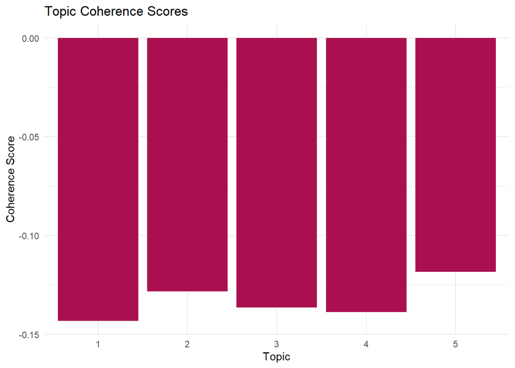

```r
# Extract beta (topic-word distributions) and ensure correct format
beta_matrix <- exp(lda_model@beta)  # Convert log probabilities to normal scale

# Extract term names from the DTM
dtm_terms <- Terms(dtm)

# Ensure beta_matrix has correct column names
colnames(beta_matrix) <- dtm_terms

# Convert DTM to a dense matrix, ensuring term names match
dtm_matrix <- as.matrix(dtm)
colnames(dtm_matrix) <- dtm_terms  # Align term names

# Remove zero-sum columns to prevent errors
dtm_matrix <- dtm_matrix[, colSums(dtm_matrix) > 0, drop = FALSE]

# Convert to a sparse matrix format required by textmineR
dtm_sparse <- as(dtm_matrix, "dgCMatrix")

# Compute coherence scores
coherence_scores <- CalcProbCoherence(beta_matrix, dtm_sparse)

# Create a dataframe for visualization
coherence_df <- data.frame(topic = 1:num_topics, coherence = coherence_scores)

# Plot coherence scores
ggplot(coherence_df, aes(x = factor(topic), y = coherence)) +
  geom_bar(stat = "identity", fill = "#AA104F") +
  labs(title = "Topic Coherence Scores", x = "Topic", y = "Coherence Score") +
  theme_minimal()
```

The image is a bar chart showing topic coherence scores for five topics. The x-axis represents different topics (1 to 5), while the y-axis shows their coherence scores, which measure how interpretable and meaningful the topics are.

The scores appear to be negative, indicating that the topics may not be well-defined or coherent. A lower coherence score suggests that the words within a topic might not be strongly related, making interpretation difficult.

This analysis is commonly used in topic modeling (e.g., LDA) to evaluate how well topics capture meaningful word groupings.

### **4.2. Interactive Topic Visualization using LDAvis**

To better interpret topics, we use LDAvis, which allows interactive exploration of topic distributions.

```r
# Extract required parameters
phi <- exp(lda_model@beta)  # Topic-term distribution
theta <- lda_model@gamma    # Document-topic distribution
vocab <- colnames(dtm)
doc_length <- rowSums(as.matrix(dtm))

# Compute term frequencies
term_frequency <- colSums(as.matrix(dtm))

# Prepare JSON for LDAvis
json_lda <- createJSON(phi = phi, theta = theta, vocab = Terms(dtm),
                       doc.length = rowSums(as.matrix(dtm)),
                       term.frequency = colSums(as.matrix(dtm)))

# Launch interactive visualization
serVis(json_lda)
```

This will open an interactive browser window to explore the topic-word relationships.

### **4.3. Topic Distribution Across Wine Types**

To gain deeper insights, we will analyze how topics are distributed across different wine variety. This will help identify whether certain themes are more prominent in specific wine categories.

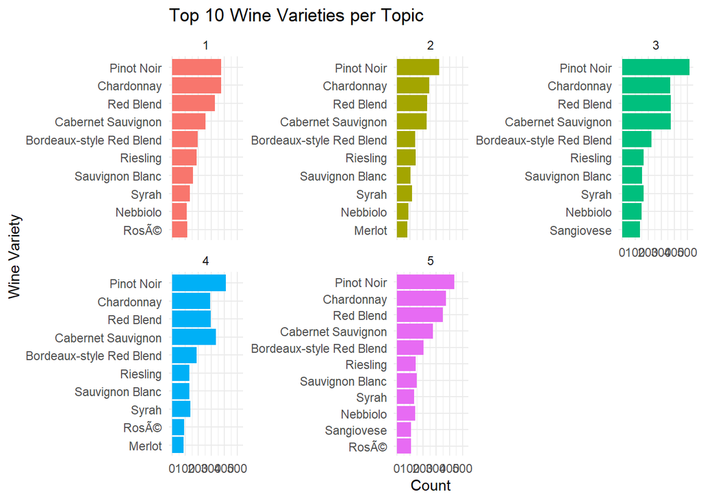

```r
set.seed(123)  # Ensures reproducibility

# Sample 20,000 rows from the dataset
df_sampled_topic <- data_clean %>% sample_n(20000)

# Remove NA and empty entries from the text column (lemmatized words)
df_sampled_topic <- df_sampled_topic %>%
  filter(!is.na(lemmatized_word) & lemmatized_word != "")

# Convert "lemmatized_word" into a Corpus
corpus <- Corpus(VectorSource(df_sampled_topic$lemmatized_word))

# Create Document-Term Matrix (DTM)
dtm <- DocumentTermMatrix(corpus)

# Remove empty documents
row_sums <- rowSums(as.matrix(dtm))
valid_docs <- row_sums > 0
dtm <- dtm[valid_docs, ]
df_filtered <- df_sampled_topic[valid_docs, ]

# Ensure DTM is not empty
if (nrow(dtm) == 0) {
  stop("Error: No valid documents after preprocessing.")
}

# Apply LDA model
num_topics <- 5  # Choose number of topics
lda_model <- LDA(dtm, k = num_topics, control = list(seed = 1234))

# Extract topic probabilities
topic_probabilities <- as.data.frame(lda_model@gamma)

# Assign dominant topic to each review
df_filtered$dominant_topic <- apply(topic_probabilities, 1, which.max)

# Identify the top 10 wine varieties per topic
variety_topic_counts <- df_filtered %>%
  group_by(variety, dominant_topic) %>%
  summarise(count = n(), .groups = "drop") %>%
  arrange(dominant_topic, desc(count)) %>%
  group_by(dominant_topic) %>%
  slice_max(count, n = 10) %>%  # Select top 10 per topic
  ungroup()

# Generate a single plot with facets for each topic
ggplot(variety_topic_counts, aes(x = reorder(variety, count), y = count, fill = as.factor(dominant_topic))) +
  geom_bar(stat = "identity") +
  coord_flip() +
  facet_wrap(~ dominant_topic, scales = "free_y") +  # Facet by dominant topic
  labs(title = "Top 10 Wine Varieties per Topic", x = "Wine Variety", y = "Count") +
  theme_minimal() +
  theme(legend.position = "none")  # Remove legend for clarity
```

### **4.4. Insights and Conclusion**

**Insights and Conclusion** The topic coherence scores from the bar chart indicate that the extracted topics might not be highly distinct or strongly coherent, as most scores are negative. This suggests that some topics could have overlapping themes, or the model may need refinement to improve clarity.

### **4.5. Future Work and Recommendations**

**Sentiment Analysis Refinement**

Future improvements could involve fine-tuning the sentiment analysis model with domain-specific wine-related lexicons or custom-trained classifiers to improve accuracy in sentiment classification.

**Advanced Topic Modeling**

Using more sophisticated models like BERTopic or hierarchical clustering could provide better topic differentiation and reveal deeper semantic relationships.

**Wine Feature Analysis**

Investigate how specific wine features (e.g., acidity, tannins, flavor notes) influence overall sentiment, potentially providing wine producers with insights to improve their products.

**User Feedback Incorporation**

Future work could involve incorporating user demographic data (age, location, etc.) to understand how different types of tasters perceive wines differently, adding a layer of segmentation to the analysis.

**Cross-Model Comparison**

Compare the results from sentiment analysis and topic modeling to see how well the sentiment aligns with the topics identified, providing a clearer understanding of the relationship between wine descriptions and tasters’ emotions.

### **4.6 Conclusion**

This study applied text mining, sentiment analysis, and topic modeling to wine reviews, revealing key insights into wine characteristics and consumer sentiment.

While the results were meaningful, refining topic coherence, expanding dataset coverage, and integrating additional features could further enhance the analysis. Future research should focus on leveraging advanced models and exploring new segmentation techniques for a deeper understanding of wine consumer preferences.